# Praca domowa 5

Kamil Grabowski

November 17, 2018

# Wstęp

Celem eksperymentu było sprawdzenie czy wyskości słupków pozwalają lepiej ocenić różnice między wartościami niż kąty, aby tego dokonać postanowiłem wykorzystać wykres składający się ze słupka z zaznaczonymi na nim wartościami przychodów poszczególnych części Toy Story (Wykres A) oraz wykres kołowy pokazujący te same dane (Wykres B).

# Wykres A

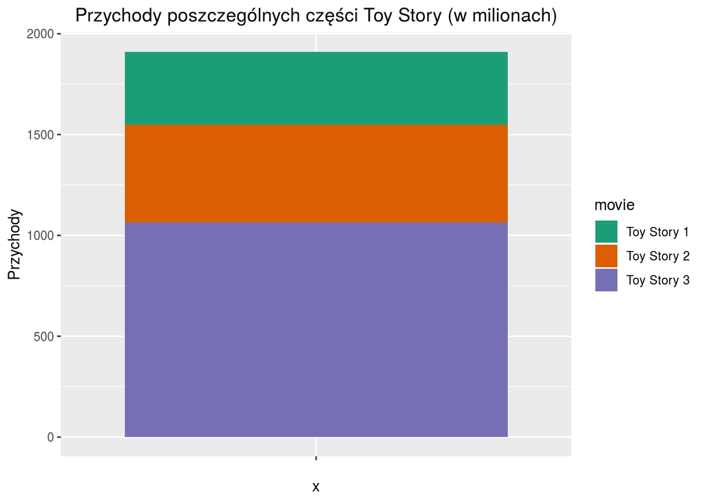

```r
 ggplot(data = data, aes(x = "", y = boxoffice, fill=movie)) +
  geom_bar(stat='identity')+
  ylab("Przychody") +
  ggtitle("Przychody poszczególnych części Toy Story (w milionach)") +
  theme(plot.title = element_text(hjust = 0.5)) + scale_fill_brewer(palette="Dark2")
```

# Wykres B

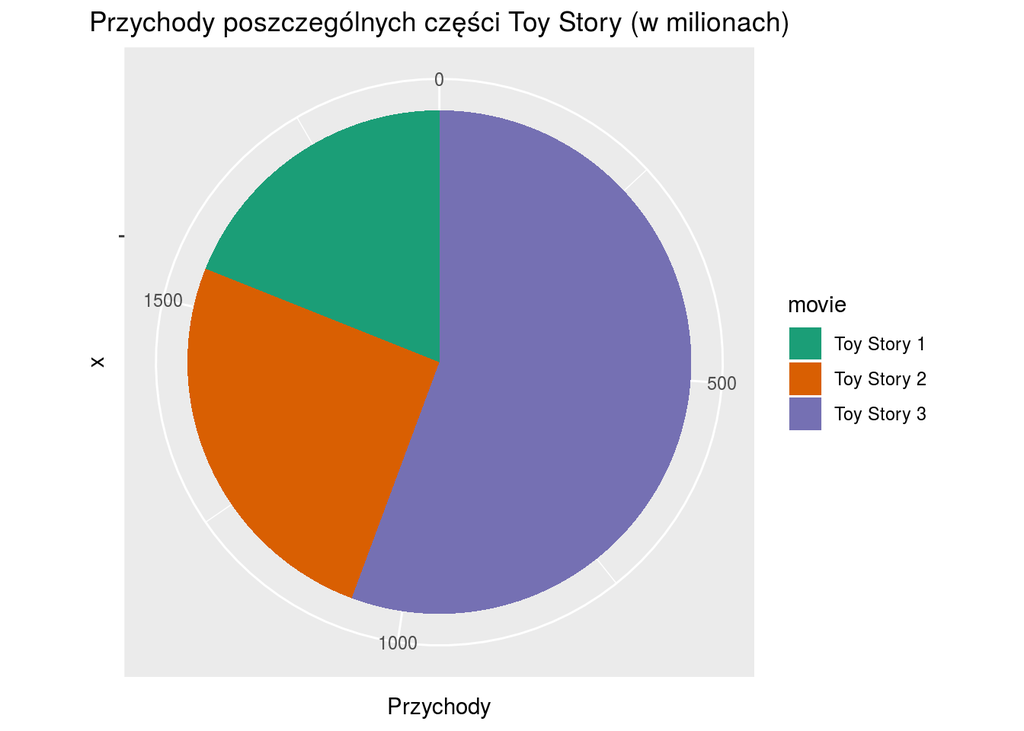

```r
 ggplot(data = data, aes(x = "", y = boxoffice, fill=movie)) +
  geom_bar(stat='identity')+
  ylab("Przychody") +
  ggtitle("Przychody poszczególnych części Toy Story (w milionach)") +
  theme(plot.title = element_text(hjust = 0.5)) +coord_polar("y", start=0) +   scale_fill_brewer(palette="Dark2")
```

# Ankieta

W ramach eksperymenty przeprowadziłem ankietę, którą można znaleźć pod adresem: https://docs.google.com/forms/d/e/1FAIpQLScBSTD-mAvvSpIZ7T7n1Qv0bXDNimVifcihuw1zMr3AHIFo8g/viewform?usp=sf_link, w której zadałem pytanie “Który wykres lepiej pozwala ocenić różnice między przychodzami poszczególnych części Toy Story?” Jej wyniki przedstawiłem poniżej.

# Wyniki

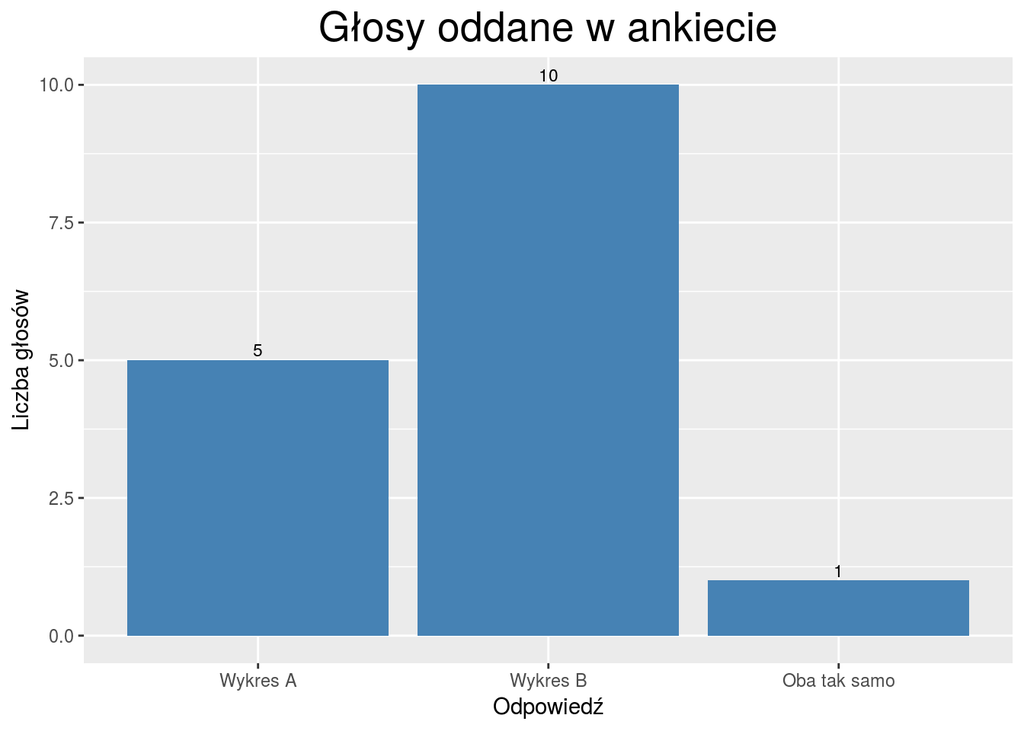

```r
names <- factor(c("Wykres A", "Wykres B", "Oba tak samo"), levels = c("Wykres A", "Wykres B", "Oba tak samo"))
votes <- c(5, 10, 1)
data_wyniki <- data.frame(names, votes)
ggplot(data = data_wyniki, aes(x=names, y=votes))+
  geom_bar(stat = 'identity', fill='steelblue') +
  ggtitle("Głosy oddane w ankiecie") +
  xlab("Odpowiedź") +
  ylab("Liczba głosów")+
  geom_text(aes(label = votes), size = 3, vjust = -0.3, color = "black") +
  theme(plot.title = element_text(hjust = 0.5, size=20))
```

# Wnioski

Wyniki eksperymetnu okazały się zaskakujące, ponieważ ludzie uznali wykres kołowy za ten, który lepiej pozwala ocenić różnice między przychodzami poszczególnych części Toy Story. Po rozmowie z niektórymi osobami, które wybrały odpowiedź B okazało się, że nie próbowali oni rzeczywiście porównać poszczególnych wartości, a swoją decyzję kierowali tym, który wykres był ładniejszy. Wykres A nie jest typowym wykresem słupkowym, ponieważ słupki położone są jeden na drugim zamiast obok siebie,ludzie nie są przyzwyczajeni do tego rodzaju wykresów co mogło mieć wpływ na ich dezyzję.